# Análise de Dados e Simulação - Lista 1

André Vinícius e Kaio Diniz

March 30, 2019

Este relatório apresentará uma análise dos dados do site https://www.citibikenyc.com/, que contém informações sobre o sistema de bicicletas para transporte público de Nova Yorque. Primeiro, apresentaremos um breve resumo sobre as variáveis contidas no dataset. Em seguida, serão feitas análises sobre a distribuição do tempo de duração das viagens, e sobre a distribuição das retiradas de bicicletas do sistema por segundo. Serão fornecidas ainda informações sobre o volume de saídas e chegadas nas estações sobre um mapa da cidade, e na análise conclusiva especularemos sobre problemas para a disponibilidade do serviço e os desafios de distribuição das bicicletas pelas estações do sistema.

# Carregando os dados

```r
bikeurl <- "https://s3.amazonaws.com/tripdata/201902-citibike-tripdata.csv.zip"
unzippedfile <- "201902-citibike-tripdata.csv"
if (!file.exists(unzippedfile))
{
  destfile <- "bikesfev.csv.zip"
  if (!file.exists(destfile))
  {
    download.file(bikeurl, destfile = destfile, method = "curl")
    downloadtime <- date()
  }
  unzip(destfile)
}
dadosbike <- read.csv(unzippedfile)
```

# Estatísticas Descritivas

O comando abaixo oferece um primeiro resumo dos dados:

```r
summary(dadosbike)
```

```
##   tripduration                          starttime
##  Min.   :     61.0   2019-02-01 08:01:31.0020:     2
##  1st Qu.:    315.0   2019-02-01 08:35:38.2480:     2
##  Median :    518.0   2019-02-01 09:17:36.5940:     2
##  Mean   :    804.8   2019-02-01 17:53:50.9470:     2
##  3rd Qu.:    879.0   2019-02-01 18:56:22.0240:     2
##  Max.   :2403037.0   2019-02-01 19:40:49.1410:     2
##                      (Other)                 :943732
##                      stoptime      start.station.id
##  2019-02-01 06:22:17.7040:     2   519    :  8084
##  2019-02-01 07:55:56.6180:     2   435    :  6303
##  2019-02-01 08:16:05.3610:     2   3255   :  5969
##  2019-02-01 08:44:28.0990:     2   497    :  5903
##  2019-02-01 08:55:24.8950:     2   402    :  5788
##  2019-02-01 13:53:16.5070:     2   285    :  5713
##  (Other)                 :943732   (Other):905984
##              start.station.name start.station.latitude
##  Pershing Square North:  8084   Min.   :40.66
##  W 21 St & 6 Ave      :  6303   1st Qu.:40.72
##  8 Ave & W 31 St      :  5969   Median :40.74
##  E 17 St & Broadway   :  5903   Mean   :40.74
##  Broadway & E 22 St   :  5788   3rd Qu.:40.76
##  Broadway & E 14 St   :  5713   Max.   :40.87
##  (Other)              :905984
##  start.station.longitude end.station.id                end.station.name
##  Min.   :-74.02          519    :  8193   Pershing Square North:  8193
##  1st Qu.:-73.99          402    :  6688   Broadway & E 22 St   :  6688
##  Median :-73.99          435    :  6303   W 21 St & 6 Ave      :  6303
##  Mean   :-73.98          3255   :  6141   8 Ave & W 31 St      :  6141
##  3rd Qu.:-73.97          497    :  5964   E 17 St & Broadway   :  5964
##  Max.   :-73.88          285    :  5794   Broadway & E 14 St   :  5794
##                          (Other):904661   (Other)              :904661
##  end.station.latitude end.station.longitude     bikeid
##  Min.   :40.66        Min.   :-74.04        Min.   :14529
##  1st Qu.:40.72        1st Qu.:-73.99        1st Qu.:26013
##  Median :40.74        Median :-73.99        Median :30929
##  Mean   :40.74        Mean   :-73.98        Mean   :28969
##  3rd Qu.:40.76        3rd Qu.:-73.97        3rd Qu.:34045
##  Max.   :40.87        Max.   :-73.88        Max.   :37907
##
##        usertype        birth.year       gender
##  Customer  : 46351   Min.   :1885   Min.   :0.000
##  Subscriber:897393   1st Qu.:1970   1st Qu.:1.000
##                      Median :1982   Median :1.000
##                      Mean   :1979   Mean   :1.177
##                      3rd Qu.:1989   3rd Qu.:1.000
##                      Max.   :2003   Max.   :2.000
##
```

Mesmo com poucas informações, esse resumo já nos revela que algumas das variáveis precisam de um tratamento. A variável “birthyear”, por exemplo, pode ser analisada também como qualitativa ordinal.

```r
tail(sort(summary(as.factor(dadosbike$birth.year))))
```

```
##  1987  1991  1988  1989  1990  1969
## 34021 36282 36914 37293 37551 46808
```

Já “gender” e “bikeid” devem ser transformadas de quantitativas para qualitativas nominais, mas sua análise não será feita nesse relatório. Mais adiante, na análise das retiradas de bicicletas do sistema, trataremos as variáveis “startitime” e “stoptime” como variáveis de tempo ao invés de strings.

# Tempo de duração das viagens

Vamos investigar melhor a variável:

```r
X <- dadosbike$tripduration
summary(X)
```

```
##      Min.   1st Qu.    Median      Mean   3rd Qu.      Max.
##      61.0     315.0     518.0     804.8     879.0 2403037.0
```

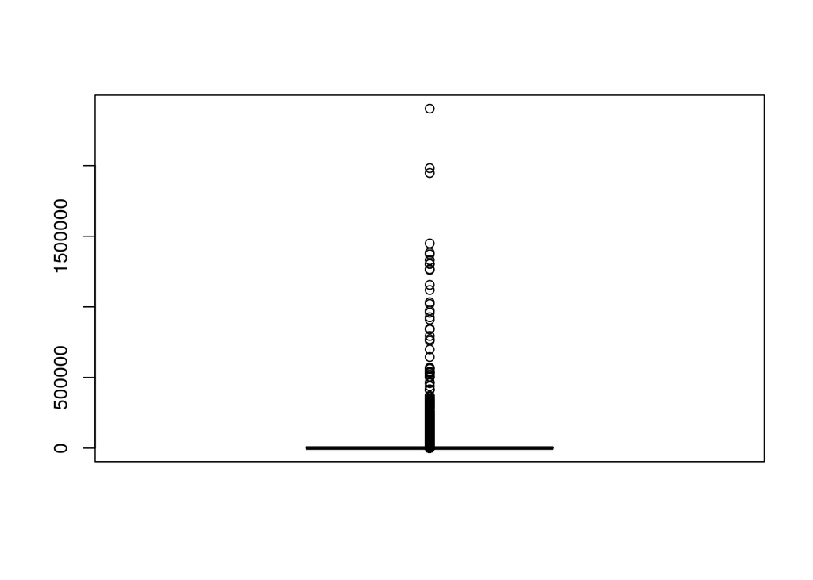

```r
boxplot(X)
```

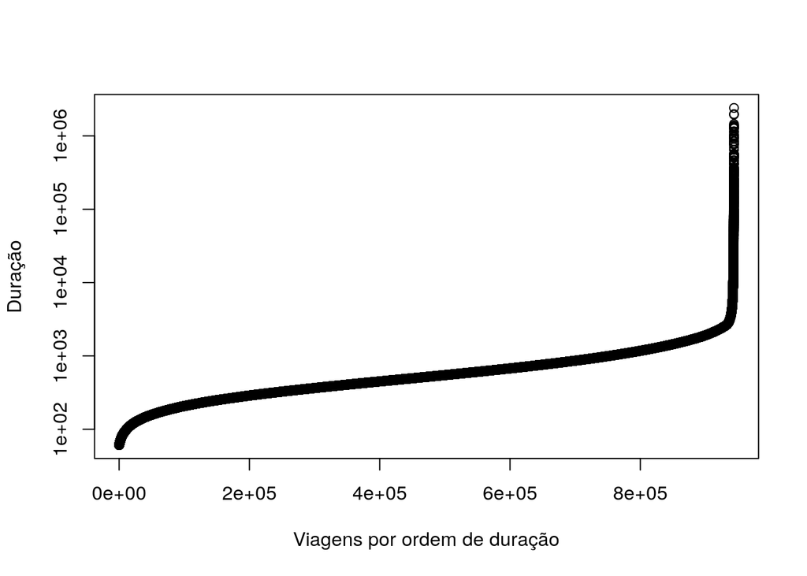

```r
plot(sort(X),
     xlab = "Viagens por ordem de duração",
     ylab = "Duração",
     log = "y")
```

Observamos que as viagens muito longas não acompanham o padrão(tivemos inclusive que colocar o eixo “y” em escala logarítimica). Isso deve acontecer por falhas no sistema em detectar se a viagem foi encerrada, usuários que levam a bicicleta para casa, etc. Em menor grau, existe também uma pequena alteração na quantidade de viagens muito curtas, mesmo com os dados começando aos 61 segundos. Vamos tentar identificar melhor esses eventos, e verificar se estes devem ser considerados na nossa análise, ou seja, se representam a duração comum das viagens. Após, alguns testes, obtivemos os intervalos:

```r
quantile(X, probs = c(0, 0.05, 0.25, 0.5, 0.75, 0.99, 1))
```

```
##      0%      5%     25%     50%     75%     99%    100%
##      61     155     315     518     879    2763 2403037
```

Com 5% das viagens durando entre 1 e 2,5 minutos, é certo que a quantidade é significativa. Já o 1% no outro extremo parece pouco representativo em relação ao comportamento que queremos analisar. Eliminando esses dados e fazendo os gráficos novamente, temos uma curva mais coerente, já com o eixo “y” na escala normal:

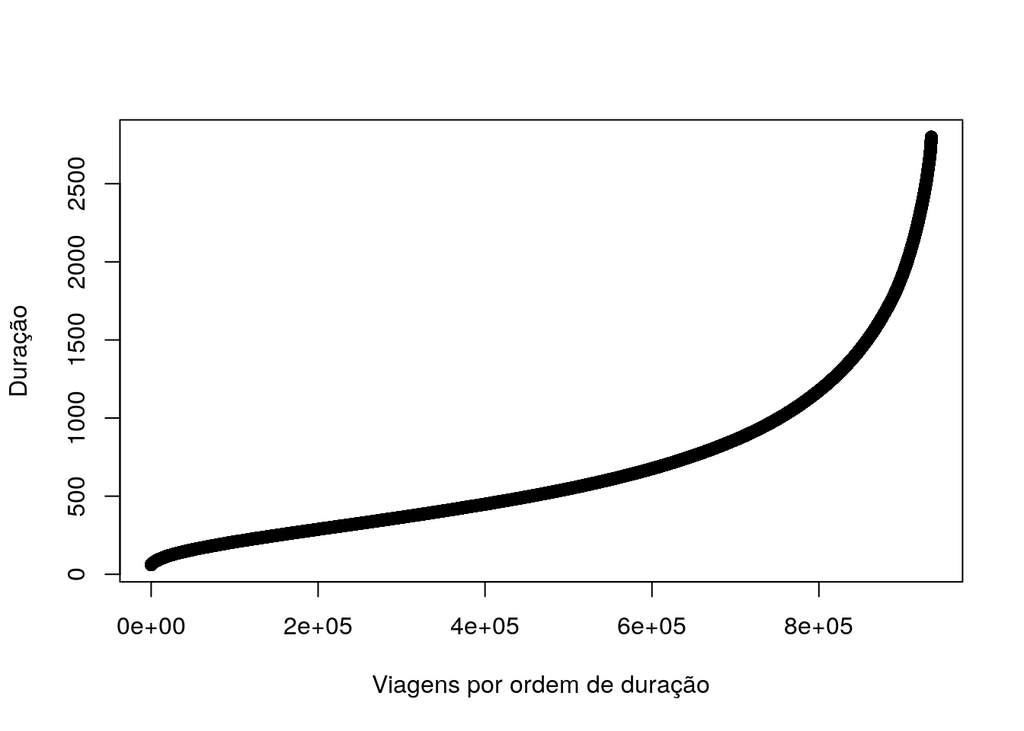

```r
plot(sort(X[X < 2800]),
     xlab = "Viagens por ordem de duração",
     ylab = "Duração")
```

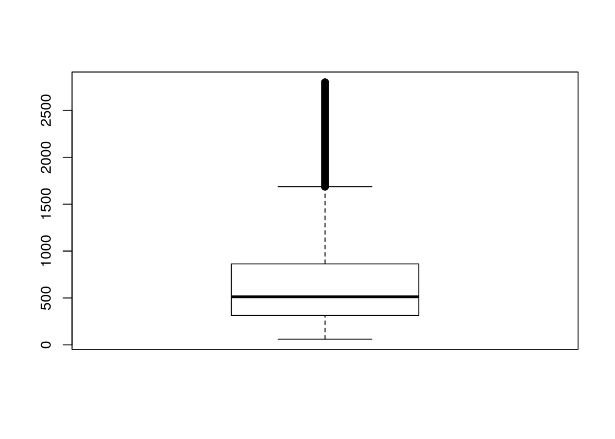

```r
boxplot(X[X < 2800])
```

# Testando se o tempo de duração (valores típicos) das viagens segue uma distribuição normal

```r
X <- dadosbike$tripduration[dadosbike$tripduration < 2800]
```

Verificando os parâmetros da variável:

```r
summary(X)
```

```
##    Min. 1st Qu.  Median    Mean 3rd Qu.    Max.
##    61.0   314.0   513.0   669.7   863.0  2799.0
```

```r
sd(X)
```

```
## [1] 505.1308
```

Baseando-se na média da nossa variável e seu desvio padrão, temos os seguintes quartis teóricos da distribuição:

```r
set.seed(1)
quantile(rnorm(n = length(X),
               mean = mean(X),
               sd = sd(X)
               ),
         probs = c(0.25, 0.5, 0.75)
         )
```

```
##       25%       50%       75%
##  329.2356  670.1579 1010.5286
```

Assim, devemos verificar que número de realizações da variável X pertence a cada um dos intervalos acima:

```r
observado <- table(cut(X, quantile(rnorm(n = length(X),
                                         mean = mean(X),
                                         sd = sd(X)),
                                   probs = c(0, 0.25, 0.5, 0.75, 1)
                                   )
                       )
                   )
esperado <- rep(length(X)/4, 4)
```

Como o total de observações é igual a 934.730, e cada um dos quartis teóricos acima deveria ter ¼ dos dados, temos que as frequências esperadas em cada um dos intervalos acima é de 233.682,5. Criando uma tabela com nossos valores e realizando o teste qui-quadrado, temos

```r
as.table(rbind(observado, esperado))
```

```
##           (-2.07e+03,329] (329,669] (669,1.01e+03] (1.01e+03,3.38e+03]
## observado        254490.0  341098.0       160291.0            178851.0
## esperado         233682.5  233682.5       233682.5            233682.5
```

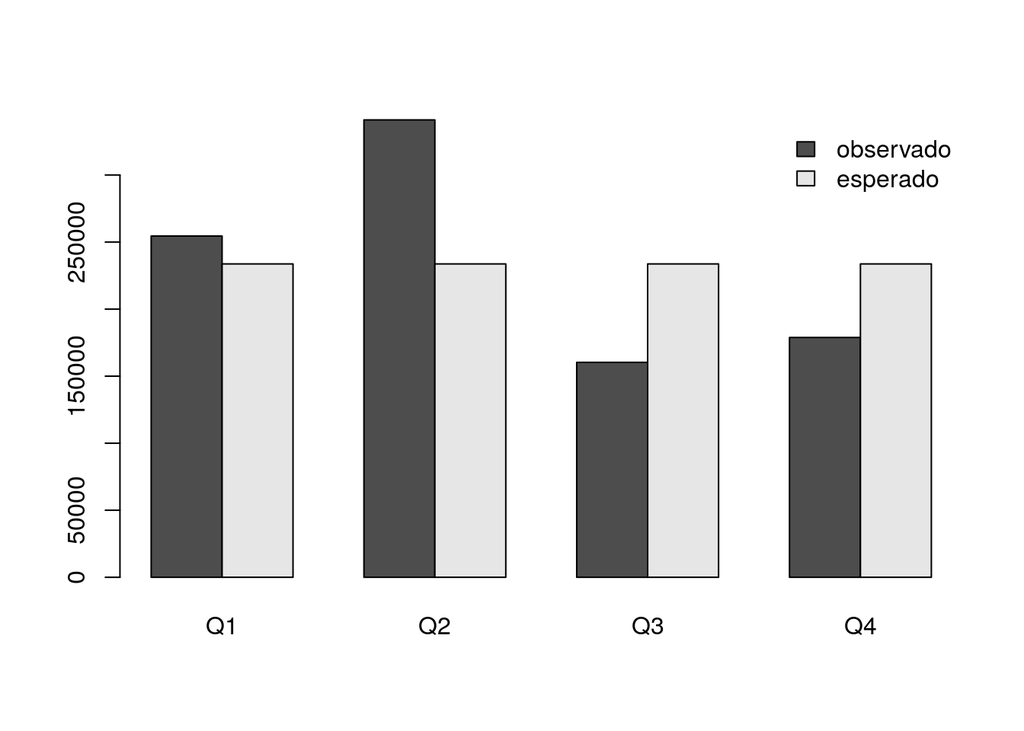

```r
M <- as.table(rbind(observado, esperado))
barplot(M,
        beside = TRUE,
        names.arg = c("Q1", "Q2", "Q3", "Q4"),
        legend.text = TRUE,
        args.legend = list(x = "topright", bty = "n"))
```

```r
chisq.test(M)
```

```
##
##  Pearson's Chi-squared test
##
## data:  M
## X-squared = 41920, df = 3, p-value < 2.2e-16
```

Sendo nossa hipótese nula “O tempo de duração típico das viagens tem uma distribuição normal”, temos que o valor-p é menor que 2,2*10^(-16). Assim, mesmo a um nível de 0.1% é possível rejeitar a hipótese, o que significa que o tempo de duração típico não segue uma distribuição normal com média 669,8 e desvio padrão igual a 505,2.

# Variáveis de começo e término das viagens(retiradas e devoluções de bicicletas)

Como já dissemos anteriormente, precisamos de alguns ajustes antes de tratar essas variáveis. Assim, poderemos estudar sua distribuição:

```r
class(dadosbike$starttime)
```

```
## [1] "factor"
```

```r
class(dadosbike$stoptime)
```

```
## [1] "factor"
```

```r
library(lubridate)
dadosbike$starttime <- ymd_hms(dadosbike$starttime)
dadosbike$stoptime <- ymd_hms(dadosbike$stoptime)
class(dadosbike$starttime)
```

```
## [1] "POSIXct" "POSIXt"
```

```r
class(dadosbike$stoptime)
```

```
## [1] "POSIXct" "POSIXt"
```

```r
summary(dadosbike$starttime)
```

```
##                  Min.               1st Qu.                Median
## "2019-02-01 00:00:06" "2019-02-07 12:27:08" "2019-02-14 19:18:08"
##                  Mean               3rd Qu.                  Max.
## "2019-02-15 01:04:04" "2019-02-22 08:48:51" "2019-02-28 23:59:59"
```

```r
summary(dadosbike$stoptime)
```

```
##                  Min.               1st Qu.                Median
## "2019-02-01 00:02:51" "2019-02-07 12:40:19" "2019-02-14 19:30:23"
##                  Mean               3rd Qu.                  Max.
## "2019-02-15 01:17:29" "2019-02-22 09:00:39" "2019-03-04 08:56:09"
```

As viagens apresentam uma certa homogeneidade entre as semanas do mês. Verificando sua distribuição entre os dias da semana, verificamos que o maior volume é durante os dias úteis. Apesar de não influenciar no objetivo final da nossa análise, a título de curiosidade, observamos que separando os dados entre “subscribers” e “customers”, o padrão de uso em relação aos dias da semana é bem diferente. Porém, como a quantidade de viagens de “customers” é muito menor, o histograma dos “subscribers” é muito próximo do da população total. O último histograma dessa sequência, da distribuição entre os dias do mês, é bem menos homogêneo.

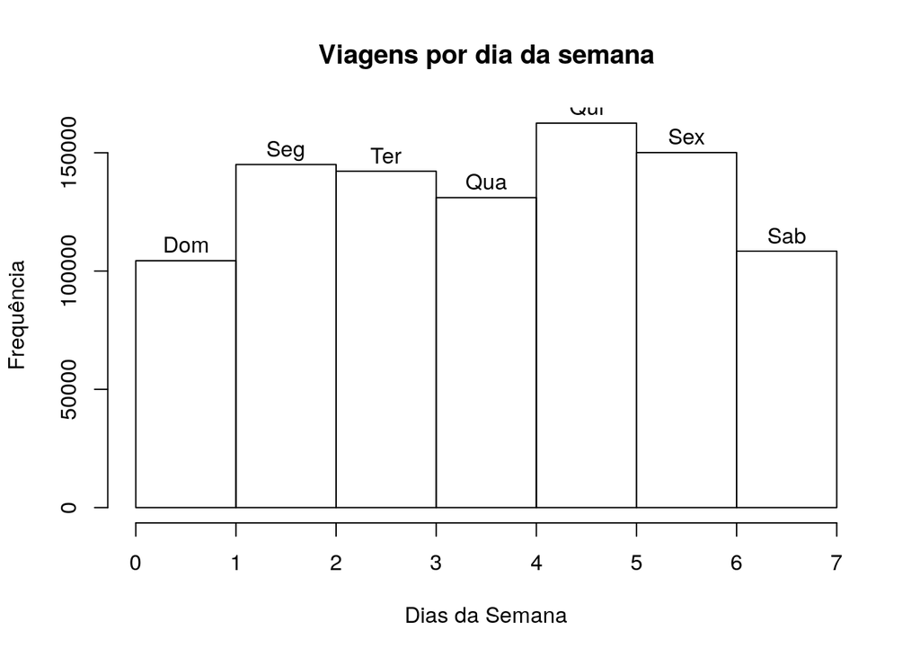

```r
# separando a hora da data
library(tidyr)
dadosbike <- separate(dadosbike,
                      starttime,
                      c("startday", "starttime"),
                      sep = " ")
dadosbike <- separate(dadosbike,
                      stoptime,
                      c("stopday", "stoptime"),
                      sep = " ")

library(dplyr)
#separando os dados que serão tratados
triptimes <- dadosbike %>%
  select(starttime,
         startday,
         stoptime,
         stopday,
         usertype,
         start.station.id,
         end.station.id)

triptimes$startday <- ymd(triptimes$startday)
triptimes$stopday <- ymd(triptimes$stopday)
triptimes$starttime <- hms(triptimes$starttime)
triptimes$stoptime <- hms(triptimes$stoptime)

#Viagens por dia da semana
hist(wday(triptimes$startday),
     breaks = 0:7,
     main = "Viagens por dia da semana",
     xlab = "Dias da Semana",
     ylab = "Frequência",
     labels = c("Dom", "Seg", "Ter", "Qua", "Qui", "Sex", "Sab")
)
```

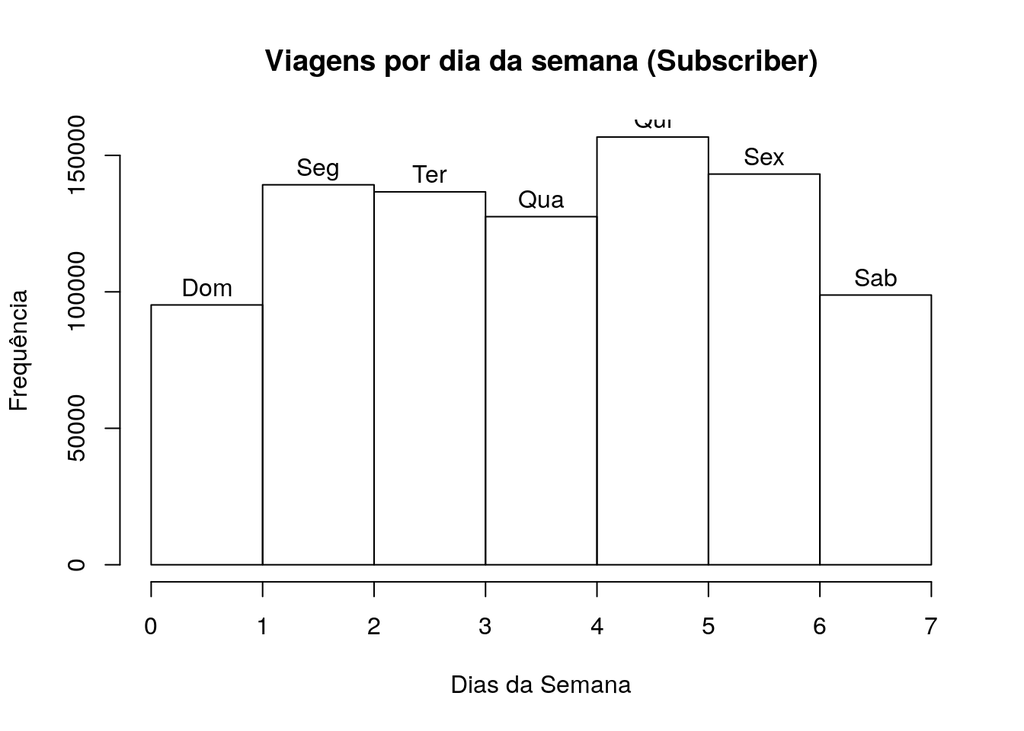

```r
# Viagens de "Subscribers"
hist(wday(triptimes$startday[triptimes$usertype == "Subscriber"]),
     breaks = 0:7,
     main = "Viagens por dia da semana (Subscriber)",
     xlab = "Dias da Semana",
     ylab = "Frequência",
     labels = c("Dom", "Seg", "Ter", "Qua", "Qui", "Sex", "Sab")
)
```

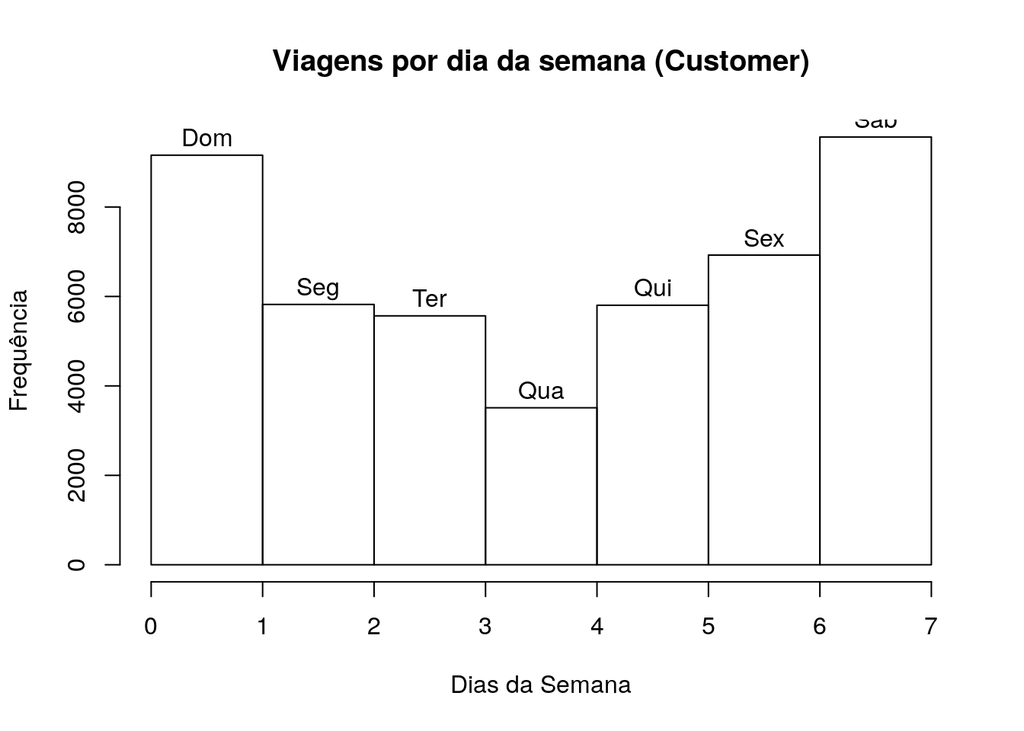

```r
#Viagens de "Customers"
hist(wday(triptimes$startday[triptimes$usertype == "Customer"]),
     breaks = 0:7,
     main = "Viagens por dia da semana (Customer)",
     xlab = "Dias da Semana",
     ylab = "Frequência",
     labels = c("Dom", "Seg", "Ter", "Qua", "Qui", "Sex", "Sab")
)
```

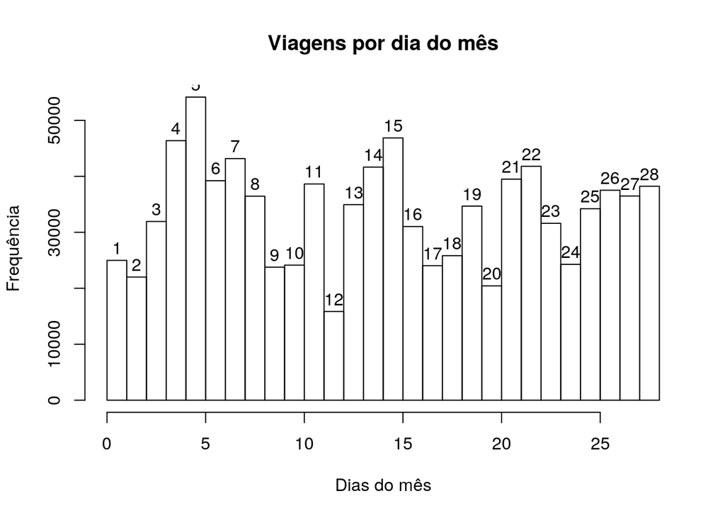

```r
#Viagens por dia do mês
hist(day(triptimes$startday),
     breaks = 0:28,
     main = "Viagens por dia do mês",
     xlab = "Dias do mês",
     ylab = "Frequência",
     labels = c(as.character(1:28))
)
```

Refinando a granularidade dos dados, encontramos mais algumas informações. Descobrimos que existem horários de pico de demanda no sistema. Dentro desses horários, encontramos uma distribuição bem homogênea entre os minutos. Decidimos então testar a possibilidade dessa demanda por bicicletas poder ser descrita por um Processo de Poisson. Como as informações da distribuição entre minutos não é precisa(o gráfico ficaria cheio de posições com “zero”), descemos mais um nível e usamos os segundos. Como nossos testes objetivam experimentar o limite de demanda no sistema, escolhemos o dia 05, às 8 horas da manhã.

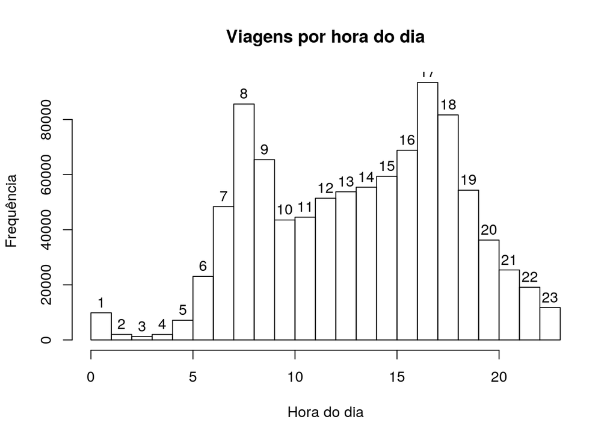

```r
hist(hour(triptimes$starttime),
     breaks = 0:23,
     main = "Viagens por hora do dia",
     xlab = "Hora do dia",
     ylab = "Frequência",
     labels = c(as.character(1:23))
)
```

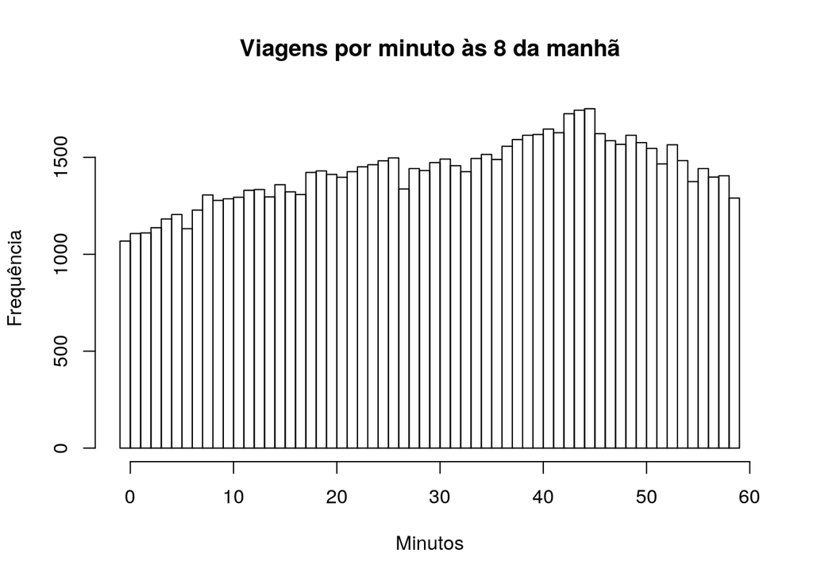

```r
hist(minute(triptimes$starttime[hour(triptimes$starttime) == 8]),
     breaks = -1:59,
     main = "Viagens por minuto às 8 da manhã",
     xlab = "Minutos",
     ylab = "Frequência")
```

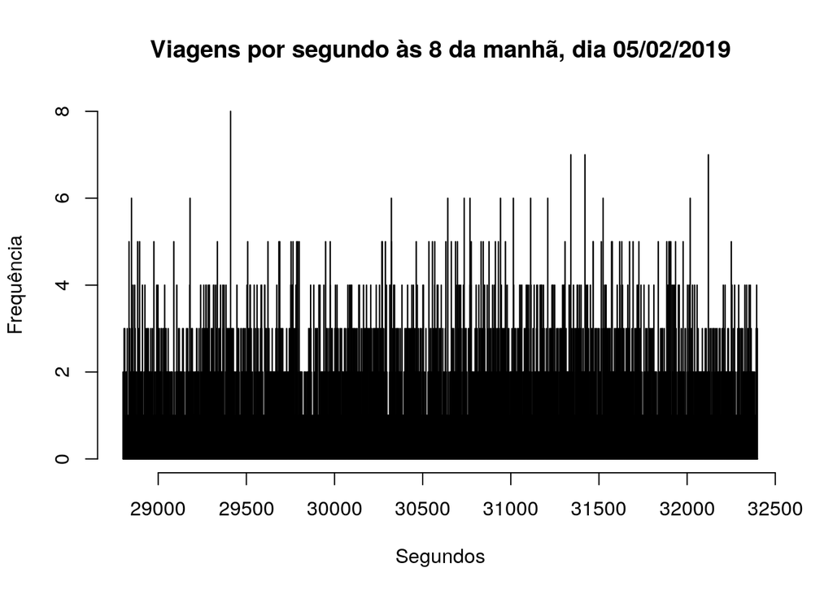

```r
hist(seconds(triptimes$starttime[hour(triptimes$starttime) == 8 &
                                   day(triptimes$startday) == 5]),
     breaks = seconds(hms("08:00:00")):seconds(hms("09:00:00")),
     main = "Viagens por segundo às 8 da manhã, dia 05/02/2019",
     xlab = "Segundos",
     ylab = "Frequência")
```

Definimos então nossa variável Y como sendo “Número de retiradas de bicicletas por segundo”.

```r
# Cada um dos segundos
cadasegundo <- as.numeric(seconds(
                          triptimes$starttime[hour(triptimes$starttime) == 8 &
                                                day(triptimes$startday) == 5]
                            )
                )
#
Yobs <- table(factor(cadasegundo,
                    levels = seconds(hms("08:00:00")):seconds(hms("09:00:00"))))
observado <- table(Yobs)
observado
```

```
## Yobs
##    0    1    2    3    4    5    6    7    8
##  809 1188  899  466  168   55   12    3    1
```

```r
set.seed(1)
Yexp <- rpois(length(Yobs), mean(Yobs))
esperado <- table(Yexp)
esperado
```

```
## Yexp
##    0    1    2    3    4    5    6    7    8
##  838 1198  852  456  192   51   10    2    2
```

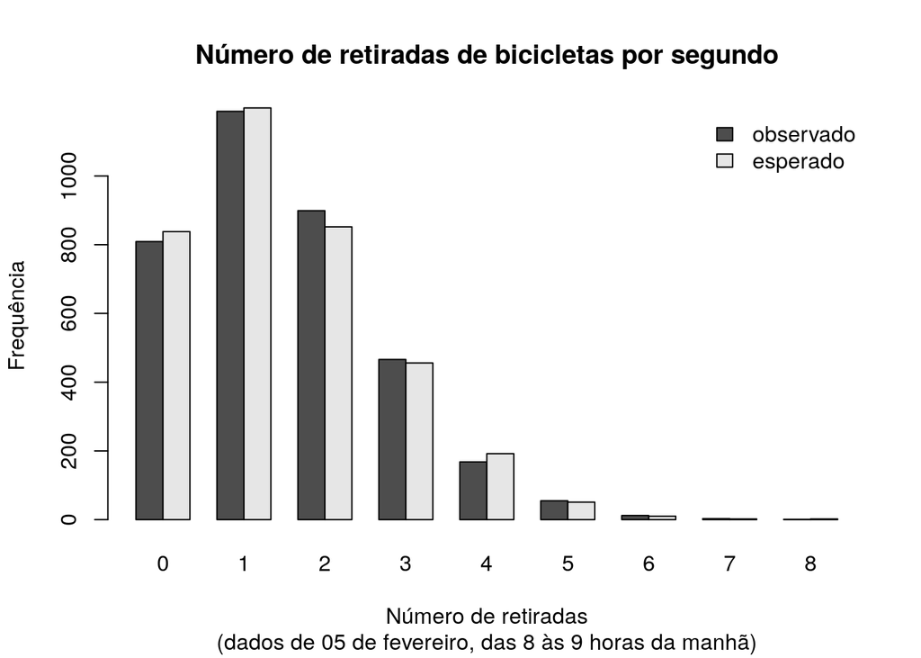

```r
P <- as.table(rbind(observado, esperado))
barplot(P,
        beside = TRUE,
        main = "Número de retiradas de bicicletas por segundo",
        sub = "(dados de 05 de fevereiro, das 8 às 9 horas da manhã)",
        xlab = "Número de retiradas",
        ylab = "Frequência",
        legend.text = TRUE,
        args.legend = list(x = "topright", bty = "n"))
```

```r
chisq.test(P)
```

```
##
##  Pearson's Chi-squared test
##
## data:  P
## X-squared = 4.3887, df = 8, p-value = 0.8205
```

Conclui-se que existem evidências na amostra, com um p-valor > 0,82, de que é verdadeira a hipótese nula “O número de retiradas de bicicletas por segundo obedece à uma Distribuição de Poisson com lambda = 1.51”.

# Análise Primária - Possibilidades a partir dos dados

Conseguimos, a partir dos dados, encontrar um processo de Poisson nas retiradas de bicicletas de um dia de pico. O procedimento pode ser repetido para as devoluções, assim como para outros dias e horários. Por outro lado, não conseguimos identificar a distribuição da duração das viagens. Mesmo assim, pudemos começar a esboçar uma idéia de como calcular a capacidade máxima do serviço. Isso pode ser obtido a partir das retiradas de bicicletas e do tempo de duração, uma vez que essas duas informações podem revelar quando o máximo de bicicletas está sendo usado ao mesmo tempo. Para finalizar, apresentamos um mapa com as estações com maior demanda de retirada, e maior número de devoluções. Observando essa última representação, percebemos que a capacidade máxima de algumas estacões pode ser atingida rapidamente, enquanto outras estações têm grande número de reposições e podem até equilibrar-se com menos intervenções. Assim, seria necessário um plano para remanejar as bicicletas disponíveis durante o dia.

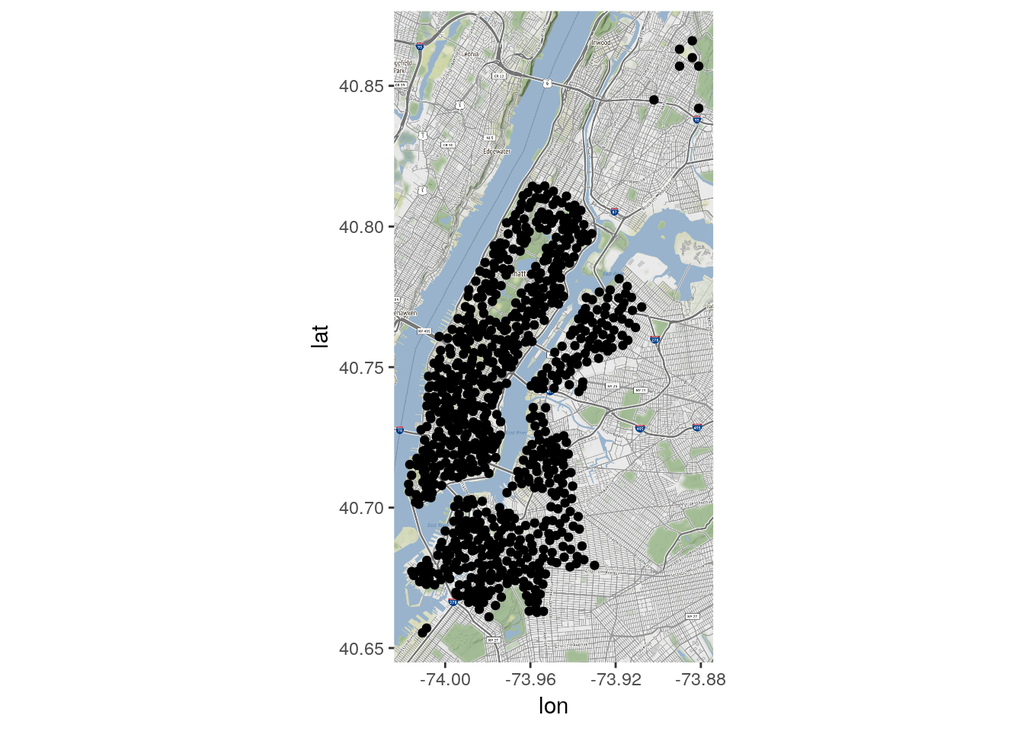

```r
library(ggmap)
x <- dadosbike$start.station.longitude
y <- dadosbike$start.station.latitude
mapinfo <- data.frame(x, y)
mapinfo <- unique(mapinfo)
bbox <- make_bbox(mapinfo$x, mapinfo$y)

#Posições das estações
get_map(bbox) %>%
  ggmap() +
  geom_point(data = mapinfo,
             aes(x = mapinfo$x,
                 y = mapinfo$y))
```

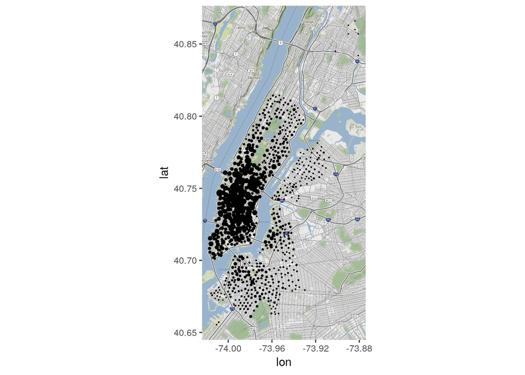

```r
start.station.count <- dadosbike %>%
  select(start.station.longitude, start.station.latitude) %>%
  count(start.station.longitude, start.station.latitude)

end.station.count <- dadosbike %>%
  select(end.station.longitude, end.station.latitude) %>%
  count(end.station.longitude, end.station.latitude)

#Começos de viagem
get_map(bbox) %>%
  ggmap() +
  geom_point(data = start.station.count,
             aes(x = start.station.longitude,
                 y = start.station.latitude),
             size = (start.station.count$n/2000))
```

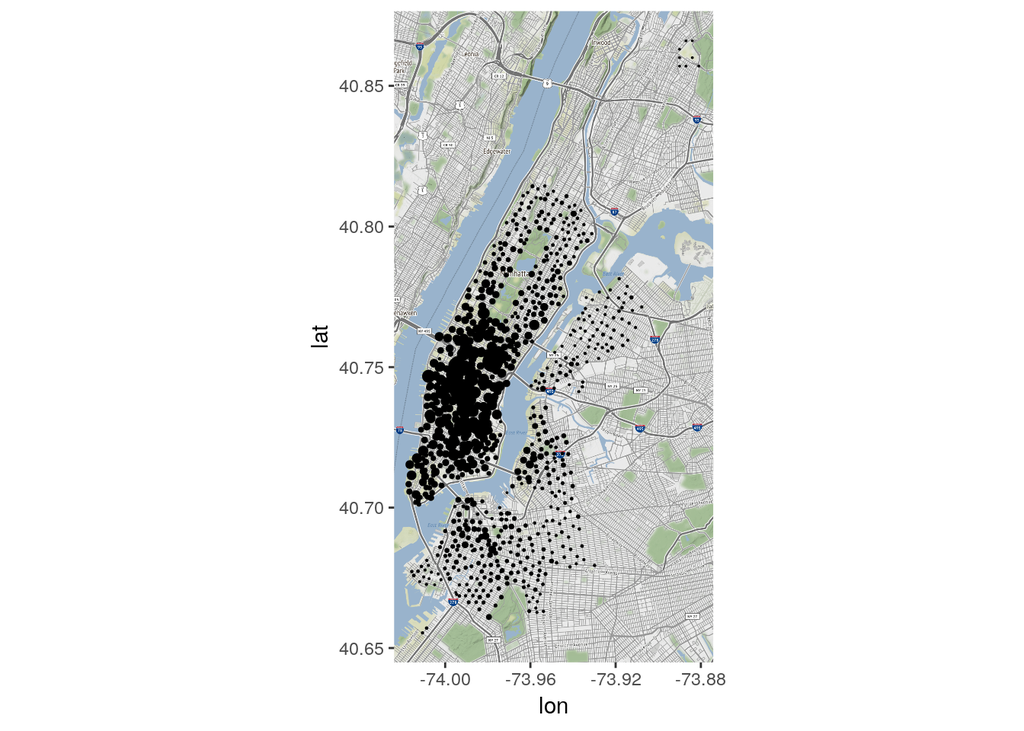

```r
# Finais de viagem
get_map(bbox) %>%
  ggmap() +
  geom_point(data = end.station.count,
             aes(x = end.station.longitude,
                 y = end.station.latitude),
             size = (end.station.count$n/2000))
```